# Soluciones 1

Sergio Camiz

2025-04-01

```r
options(width = 300)                                        # ancho de página
library(readODS)                                            # para leer .ods
```

# Construir

*una carpeta Ejercicio₁*

Hecho

# Bajar desde Paideia

y colocar en la carpeta: SudAmerica.csv,  
Baseball.csv,  
Students.csv,  
Clase1.R,  
Eggsorg.ods  
Eggs.Rmd  
Eggs.html

Bajado

# Abrir Rstudio

en la carpeta misma: si hay .Rdata es suficiente de cliquear sobre este si hay un archivo de comandos.R o .Rmd abrir como Rstudio

Aquí me pongo en la carapeta misma como carpeta de trabajo:

```r
setwd("/Work/Lavoro/PUCP/Corso PUCP 2025 - Modelo Lineal/Lezioni 2025/Clase_1 - Introducción/Esercizi")                      # carpeta de trabajo
```

# cargar Eggs.Rmd

y guardar como Ejercicio_1.Rmd.

Los pedazos siguientes constituyen Eggs.Rmd

## Ejemplo de lectura de datos

Las opciones en la primera fila impiden la elaboración de las instrucciones, que van ser reorganizadas en seguida.

Corregir siguiendo el Eggs.html y correr paso a paso, incluyendo comentarios sobre los resultados.

## Reorganización y comentarios

El pedazo siguiente tiene comandos que necesitan ser incluidos al principio del documento, así que seran desplazados allí. Nótese que al nombre del pedazo se han ajuntado “echo=TRUE, include=FALSE, eval=FALSE”. Estos permiten de ver el pedazo en la salida, de ver los resultados. De hecho, se le indica de no verlos, ni siqueira di correr el pedazo mismo.

```r
knitr::opts_chunk$set(echo = TRUE)
options(width = 300)
library(readODS)
```

Aquí en seguida se lee la hoja 1 contenida en Eggsorg.ods.

Sacamos datos de uevos de pajaros de una hoja electrónica construida a partir de un pdf. Si la hoja se ha guardado también en formado .csv, o sea con texto con separador comas, se usa la función read.csv().

```r
eggs               <- read.csv("Eggs.csv",
                               header=TRUE,row.names=1)     # lectura datos
head(eggs)                                                  # control
```

```
##                 Family Size      Nesting.ground  Eggs Length Width Mass Hatch
## Barn owl           Owl 34.0 Hollow trees, barns   4-7   39.2  30.8 20.7    30
## Black cap      Warbler 14.0   Bushes, low trees   4-6   19.6  14.7  1.9 14-15
## Black redstaft    Chat 14.0     Hales, crevices   5-6   19.4  14.4  2.0    13
## Blackbird       Thrush 25.0       Trees, bushes   4-6   28.6  21.0  9.0 13-14
## Blue tit           Tit 11.5               Holes 10-13   15.4  11.9  1.3 13-15
## Brambling        Finch 14.5       Trees, bushes   5-6   19.5  14.6  2.2 12-13
```

```r
str(eggs)                                                   # estructura data-frame
```

```
## 'data.frame':    96 obs. of  8 variables:
##  $ Family        : chr  "Owl" "Warbler" "Chat" "Thrush" ...
##  $ Size          : num  34 14 14 25 11.5 14.5 15 95 47 15 ...
##  $ Nesting.ground: chr  "Hollow trees, barns" "Bushes, low trees" "Hales, crevices" "Trees, bushes" ...
##  $ Eggs          : chr  "4-7" "4-6" "5-6" "4-6" ...
##  $ Length        : num  39.2 19.6 19.4 28.6 15.4 19.5 20.2 85.7 43.5 19.3 ...
##  $ Width         : num  30.8 14.7 14.4 21 11.9 14.6 15.1 58.2 30.1 14.6 ...
##  $ Mass          : num  20.7 1.9 2 9 1.3 2.2 2.1 228 19 2.1 ...
##  $ Hatch         : chr  "30" "14-15" "13" "13-14" ...
```

```r
print(eggs)                                                 # salida
```

```
##                         Family Size          Nesting.ground  Eggs Length Width  Mass Hatch
## Barn owl                   Owl 34.0     Hollow trees, barns   4-7   39.2  30.8  20.7    30
## Black cap              Warbler 14.0       Bushes, low trees   4-6   19.6  14.7   1.9 14-15
## Black redstaft            Chat 14.0         Hales, crevices   5-6   19.4  14.4   2.0    13
## Blackbird               Thrush 25.0           Trees, bushes   4-6   28.6  21.0   9.0 13-14
## Blue tit                   Tit 11.5                   Holes 10-13   15.4  11.9   1.3 13-15
## Brambling                Finch 14.5           Trees, bushes   5-6   19.5  14.6   2.2 12-13
## Bullfinch                Finch 15.0        Bushes, conifers   4-5   20.2  15.1   2.1    13
## Canada goose             Goose 95.0         Islets, marshes   5-6   85.7  58.2 228.0 28-30
## Carrion crow              Crow 47.0              Tall trees   4-6   43.5  30.1  19.0 17-19
## Chaffinch                Finch 15.0   Bushes, trees, hedges   4-6   19.3  14.6   2.1 12-13
## Chiff-chaff            Warbler 11.0  Wood verges, hedgerows   5-6   15.5  12.0   1.3 13-14
## Chough                    Crow 39.0 Crevices, cliff, ledges   3-5   39.4  27.9  13.0 19-21
## Cirl bunting           Bunting 16.0          Bushes, hedges   3-5   20.9  15.9   2.8 11-13
## Coal tit                   Tit 11.0          Holes, burrows  7-10   14.7  11.6   1.4 14-16
## Collared dove           Pigeon 32.0           Trees, bushes     2   31.9  24.0   8.5 15-16
## Common sandpiper     Sandpiper 20.0             Lake shores     4   36.3  36.0  12.0 21-22
## Corn bunting           Bunting 18.0          Grassy hollows   5-6   23.8  17.7   3.7 12-13
## Crested tit                Tit 11.5              Tree hales   5-7   16.0  12.4   1.3 15-18
## Crossbill                Finch 16.0                Conifers   3-4   22.1  16.1   2.9 12-13
## Dotterel                Plover 22.0            Moors, scree   2-4   41.1  28.9  11.0 27-28
## Dunlin               Sandpiper 18.0          Moors, marshes   3-5   34.7  24.7  11.0    17
## Eider                     Duck 60.0        Near sea, islets   4-6   77.6  51.9 110.3 25-26
## Fieldfare               Thrush 26.0          Woodland trees   5-6   28.8  20.9   7.0 13-14
## Firecrest              Warbler  9.0                Conifers  7-12   13.5  10.3   0.7 14-15
## Gadwall                   Duck 51.0                Reedbeds  8-12   51.8  37.5  42.5    26
## Garden warbler         Warbler 14.0        Shrubs, brambles   4-5   20.1  14.8   2.5    12
## Garganey                  Duck 39.0  Dry ground, vegetation  8-11   45.3  33.3  25.7 21-23
## Goldcrest              Warbler  9.0           Tall conifers  8-11   13.6  10.3   0.7    16
## Golden Plover           Plover 28.0             Boggy moors     4   51.8  35.9  34.0    27
## Goldeneye                 Duck 46.0     Tree holes, burrows  6-11   58.4  43.2  56.5    30
## Goldfinch                Finch 12.0                   Trees   5-6   17.0  12.8   1.4 12-13
## Goosander                 Duck 62.0              Tree holes  8-12   66.4  46.4  83.5    32
## Grasshopper warbler    Warbler 13.0          Moors, marshes   5-6   18.1  13.8   1.7 13-15
## Great tit                  Tit 14.0              Tree holes  7-10   17.3 135.0   1.6 13-14
## Green sandpiper      Sandpiper 23.0  Trees on marshy ground     4   39.1  28.0  16.0 20-22
## Greenfinch               Finch 14.5          Bushes, hedges     5   20.2  14.5   2.0 13-14
## Grey wagtail           Wagtail 18.0           Holes, ledges   5-6   19.0  14.5   1.9 12-14
## Greylag goose            Goose 83.0                Reedbeds   5-8   85.3  58.0 176.0 28-29
## Howlinch                 Finch 18.0         Deciduous trees   5-6   24.5  17.5   3.4    14
```

[output cut: 42 more lines]

```
## Teal                      Duck 36.0  Dry ground, vegetotion     5   45.6  33.5  26.8 21-22
## Temminck's stint     Sandpiper 14.0                  Islets     4   28.0  20.4   6.0 13-14
## Tree sparrow           Sparrow 14.0         Holes, crevices   5-6   19.3  14.0   2.0 13-14
## Turtle dove             Pigeon 32.0           Trees, hedges   2-3   30.7  23.0   9.0 13-15
## Twite                    Finch 13.0            Ground cover   5-6   17.2  12.9   1.5 12-13
## Wheatear                  Chat 15.0          Holes, burrows   5-6   21.2  15.9   2.5    14
## Whinchat                  Chat 12.5          Grassy hollows   5-7   19.2  14.8   2.0 13-14
## Whitethroat            Warbler 14.0           Scrub, bushes   4-5   18.1  13.8   2.0 11-13
## Wigeon                    Duck 48.0    Islets, ground cover     9   53.9  38.2  44.0 22-23
## Wood sandpiper       Sandpiper 20.0             Boggy moors     4   38.3  27.0  13.0 21-24
## Wood warbler           Warbler 13.0         Woodland ground   5-6   16.1  12.6   1.3    13
## Wood-pigeon             Pigeon 41.0           Trees, bushes   2-3   40.1  28.7  18.5 15-17
## Woodlark                  Lork 15.0             Wood verges   3-4   21.6  16.3   2.7 13-15
## Yellow wagtail         Wagtail 16.5          Grassy hollows   5-6   19.1  14.3   1.9 13-14
## Yellowhammer           Bunting 16.5          Grassy hollows   3-5   21.2  15.9   2.7 12-14
```

Se puede usar directamente la función read_ods() del pacote readODS, que se ha hecho disponible arriba. Pero hay unos problemas.

```r
eggs               <- read_ods("Eggsorg.ods", sheet = 1)    # lectura datos
head(eggs)                                                  # control
```

```
## # A tibble: 6 × 9
##   Name           Family   Size `Nesting ground`    Eggs  Length Width  Mass Hatch
##   <chr>          <chr>   <dbl> <chr>               <chr>  <dbl> <dbl> <dbl> <chr>
## 1 Barn owl       Owl      34   Hollow trees, barns 4-7     39.2  30.8  20.7 30
## 2 Black cap      Warbler  14   Bushes, low trees   4-6     19.6  14.7   1.9 14-15
## 3 Black redstaft Chat     14   Hales, crevices     5-6     19.4  14.4   2   13
## 4 Blackbird      Thrush   25   Trees, bushes       4-6     28.6  21     9   13-14
## 5 Blue tit       Tit      11.5 Holes               10-13   15.4  11.9   1.3 13-15
## 6 Brambling      Finch    14.5 Trees, bushes       5-6     19.5  14.6   2.2 12-13
```

```r
str(eggs)                                                   # estructura data-frame
```

```
## tibble [96 × 9] (S3: tbl_df/tbl/data.frame)
##  $ Name          : chr [1:96] "Barn owl" "Black cap" "Black redstaft" "Blackbird" ...
##  $ Family        : chr [1:96] "Owl" "Warbler" "Chat" "Thrush" ...
##  $ Size          : num [1:96] 34 14 14 25 11.5 14.5 15 95 47 15 ...
##  $ Nesting ground: chr [1:96] "Hollow trees, barns" "Bushes, low trees" "Hales, crevices" "Trees, bushes" ...
##  $ Eggs          : chr [1:96] "4-7" "4-6" "5-6" "4-6" ...
##  $ Length        : num [1:96] 39.2 19.6 19.4 28.6 15.4 19.5 20.2 85.7 43.5 19.3 ...
##  $ Width         : num [1:96] 30.8 14.7 14.4 21 11.9 14.6 15.1 58.2 30.1 14.6 ...
##  $ Mass          : num [1:96] 20.7 1.9 2 9 1.3 2.2 2.1 228 19 2.1 ...
##  $ Hatch         : chr [1:96] "30" "14-15" "13" "13-14" ...
```

Los datos se han sacado, pero se resulta el nombre del pajaro como una variable de tipo caracter. Por tanto, se necesita indicar que la primera columna tiene etiquetas. Por esto hay también que indicar que queremos conseguir un data.frame y no un “tibble”.

```r
eggs               <- read_ods("Eggsorg.ods", sheet = 1,
                               row_names = TRUE, as_tibble = FALSE) # lectura con etiquetas
head(eggs)
```

```
##                          Family Size      Nesting ground  Eggs Length Width Mass Hatch
## Barn owl                    Owl 34.0 Hollow trees, barns   4-7   39.2  30.8 20.7    30
## Black cap               Warbler 14.0   Bushes, low trees   4-6   19.6  14.7  1.9 14-15
## Black redstaft             Chat 14.0     Hales, crevices   5-6   19.4  14.4  2.0    13
## Blackbird                Thrush 25.0       Trees, bushes   4-6   28.6  21.0  9.0 13-14
## Blue tit                    Tit 11.5               Holes 10-13   15.4  11.9  1.3 13-15
## Brambling                 Finch 14.5       Trees, bushes   5-6   19.5  14.6  2.2 12-13
```

```r
str(eggs)
```

```
## 'data.frame':    96 obs. of  8 variables:
##  $ Family        : chr  "Owl" "Warbler" "Chat" "Thrush" ...
##  $ Size          : num  34 14 14 25 11.5 14.5 15 95 47 15 ...
##  $ Nesting ground: chr  "Hollow trees, barns" "Bushes, low trees" "Hales, crevices" "Trees, bushes" ...
##  $ Eggs          : chr  "4-7" "4-6" "5-6" "4-6" ...
##  $ Length        : num  39.2 19.6 19.4 28.6 15.4 19.5 20.2 85.7 43.5 19.3 ...
##  $ Width         : num  30.8 14.7 14.4 21 11.9 14.6 15.1 58.2 30.1 14.6 ...
##  $ Mass          : num  20.7 1.9 2 9 1.3 2.2 2.1 228 19 2.1 ...
##  $ Hatch         : chr  "30" "14-15" "13" "13-14" ...
```

```r
write.csv(eggs, file = "Eggs.csv")                          # escritura .csv
```

Ahora los nombres resultan como etiquetas, pero mirando a los datos que resultan en el archivo .csv se ve que en las etiquetas hay espacios. Esto debido a que los datos se han cargado en la hoja con espacios de todo lado, que como datos se han limpiado, pero no como etiquetas.

Le tiramos los espacios, igualmente limpiamos las etiquetas de las variables, que aparecen con varios caracteres más.

```r
rownames(eggs)     <- trimws(rownames(eggs),
                             which = c("both"))             # se tiran los espacios
colnames(eggs)                                              # etiquetas columnas
```

```
## [1] "Family"         "Size"           "Nesting ground" "Eggs"           "Length"         "Width"          "Mass"           "Hatch"
```

```r
colnames(eggs) <- c("Family","Size","Nesting ground","Eggs",
                    "Length","Width","Mass","Hatch")        # se copian sin espacios
print(eggs)                                                 # se veen los datos
```

```
##                         Family Size          Nesting ground  Eggs Length Width  Mass Hatch
## Barn owl                   Owl 34.0     Hollow trees, barns   4-7   39.2  30.8  20.7    30
## Black cap              Warbler 14.0       Bushes, low trees   4-6   19.6  14.7   1.9 14-15
## Black redstaft            Chat 14.0         Hales, crevices   5-6   19.4  14.4   2.0    13
## Blackbird               Thrush 25.0           Trees, bushes   4-6   28.6  21.0   9.0 13-14
## Blue tit                   Tit 11.5                   Holes 10-13   15.4  11.9   1.3 13-15
## Brambling                Finch 14.5           Trees, bushes   5-6   19.5  14.6   2.2 12-13
## Bullfinch                Finch 15.0        Bushes, conifers   4-5   20.2  15.1   2.1    13
## Canada goose             Goose 95.0         Islets, marshes   5-6   85.7  58.2 228.0 28-30
## Carrion crow              Crow 47.0              Tall trees   4-6   43.5  30.1  19.0 17-19
## Chaffinch                Finch 15.0   Bushes, trees, hedges   4-6   19.3  14.6   2.1 12-13
## Chiff-chaff            Warbler 11.0  Wood verges, hedgerows   5-6   15.5  12.0   1.3 13-14
## Chough                    Crow 39.0 Crevices, cliff, ledges   3-5   39.4  27.9  13.0 19-21
## Cirl bunting           Bunting 16.0          Bushes, hedges   3-5   20.9  15.9   2.8 11-13
## Coal tit                   Tit 11.0          Holes, burrows  7-10   14.7  11.6   1.4 14-16
## Collared dove           Pigeon 32.0           Trees, bushes     2   31.9  24.0   8.5 15-16
## Common sandpiper     Sandpiper 20.0             Lake shores     4   36.3  36.0  12.0 21-22
## Corn bunting           Bunting 18.0          Grassy hollows   5-6   23.8  17.7   3.7 12-13
## Crested tit                Tit 11.5              Tree hales   5-7   16.0  12.4   1.3 15-18
## Crossbill                Finch 16.0                Conifers   3-4   22.1  16.1   2.9 12-13
## Dotterel                Plover 22.0            Moors, scree   2-4   41.1  28.9  11.0 27-28
## Dunlin               Sandpiper 18.0          Moors, marshes   3-5   34.7  24.7  11.0    17
## Eider                     Duck 60.0        Near sea, islets   4-6   77.6  51.9 110.3 25-26
## Fieldfare               Thrush 26.0          Woodland trees   5-6   28.8  20.9   7.0 13-14
## Firecrest              Warbler  9.0                Conifers  7-12   13.5  10.3   0.7 14-15
## Gadwall                   Duck 51.0                Reedbeds  8-12   51.8  37.5  42.5    26
## Garden warbler         Warbler 14.0        Shrubs, brambles   4-5   20.1  14.8   2.5    12
## Garganey                  Duck 39.0  Dry ground, vegetation  8-11   45.3  33.3  25.7 21-23
## Goldcrest              Warbler  9.0           Tall conifers  8-11   13.6  10.3   0.7    16
## Golden Plover           Plover 28.0             Boggy moors     4   51.8  35.9  34.0    27
## Goldeneye                 Duck 46.0     Tree holes, burrows  6-11   58.4  43.2  56.5    30
## Goldfinch                Finch 12.0                   Trees   5-6   17.0  12.8   1.4 12-13
## Goosander                 Duck 62.0              Tree holes  8-12   66.4  46.4  83.5    32
## Grasshopper warbler    Warbler 13.0          Moors, marshes   5-6   18.1  13.8   1.7 13-15
## Great tit                  Tit 14.0              Tree holes  7-10   17.3 135.0   1.6 13-14
## Green sandpiper      Sandpiper 23.0  Trees on marshy ground     4   39.1  28.0  16.0 20-22
## Greenfinch               Finch 14.5          Bushes, hedges     5   20.2  14.5   2.0 13-14
## Grey wagtail           Wagtail 18.0           Holes, ledges   5-6   19.0  14.5   1.9 12-14
## Greylag goose            Goose 83.0                Reedbeds   5-8   85.3  58.0 176.0 28-29
## Howlinch                 Finch 18.0         Deciduous trees   5-6   24.5  17.5   3.4    14
```

[output cut: 42 more lines]

```
## Teal                      Duck 36.0  Dry ground, vegetotion     5   45.6  33.5  26.8 21-22
## Temminck's stint     Sandpiper 14.0                  Islets     4   28.0  20.4   6.0 13-14
## Tree sparrow           Sparrow 14.0         Holes, crevices   5-6   19.3  14.0   2.0 13-14
## Turtle dove             Pigeon 32.0           Trees, hedges   2-3   30.7  23.0   9.0 13-15
## Twite                    Finch 13.0            Ground cover   5-6   17.2  12.9   1.5 12-13
## Wheatear                  Chat 15.0          Holes, burrows   5-6   21.2  15.9   2.5    14
## Whinchat                  Chat 12.5          Grassy hollows   5-7   19.2  14.8   2.0 13-14
## Whitethroat            Warbler 14.0           Scrub, bushes   4-5   18.1  13.8   2.0 11-13
## Wigeon                    Duck 48.0    Islets, ground cover     9   53.9  38.2  44.0 22-23
## Wood sandpiper       Sandpiper 20.0             Boggy moors     4   38.3  27.0  13.0 21-24
## Wood warbler           Warbler 13.0         Woodland ground   5-6   16.1  12.6   1.3    13
## Wood-pigeon             Pigeon 41.0           Trees, bushes   2-3   40.1  28.7  18.5 15-17
## Woodlark                  Lork 15.0             Wood verges   3-4   21.6  16.3   2.7 13-15
## Yellow wagtail         Wagtail 16.5          Grassy hollows   5-6   19.1  14.3   1.9 13-14
## Yellowhammer           Bunting 16.5          Grassy hollows   3-5   21.2  15.9   2.7 12-14
```

```r
write_ods(eggs, "Eggs.ods", sheet = "Data",                 # nueva hoja
          row_names = TRUE, col_names = TRUE)
write.csv(eggs, file = "Eggs.csv")                          # nuevo .csv
```

Los archivos guardados se resultan correctos.

# cargar Clase1.R

y incluir en el archivo Ejercicio_1.Rmd,

```r
#########################################################################################
# Lectura de los datos y primeros gráficos
#setwd(<aquí ponen el nombre de la carpeta donde tienen sus datos)
SudAmerica <- read.csv("SudAmerica.csv", row.names = 1) # lectura del archivo eventualmente read.table con sus opciones
attach(SudAmerica)                                  # archivo en uso
lab        <- rownames(SudAmerica)                  # etiquetas de las unidades en lab
plot(Tajo_urbano,IDH,xlab="Tajo_urbano",ylab="IDH") # diagrama de dispersión de dos carácteres
text(Tajo_urbano,IDH,lab)                           # escritura de etiquetas sobre el gráfico
plot(Tajo_urbano,IDH,xlab="Tajo_urbano",ylab="IDH") # otro diagrama
identify(Tajo_urbano,IDH,lab)                       # escritura de etiquetas cliqueando cadauna

#########################################################################################
# regresión lm dibujo de datos con recta y predictos
attach(SudAmerica)
plot(Tajo_urbano,IDH,xlab="Tajo_urbano",ylab="IDH") # otro diagrama
identify(Tajo_urbano,IDH,lab)                       # escritura de etiquetas cliqueando cadauna
lmSA       <- lm(IDH~Tajo_urbano,data=SudAmerica)   # regresión
abline(lmSA,col="red")                              # se traza la recta estimada
points(Tajo_urbano,lmSA$fitted.values,col="red")    # y los IDH estimados

# salida de resultados y graficós estándar
summary(lmSA)
plot(lmSA)
#########################################################################################
```

y modificar para cargar SudAmerica, Baseball, Student (midterm, final) con read.csv, luego guardar los datos como hojas .ods y comentar

```r
SudAmerica         <- read.csv("SudAmerica.csv",
                               row.names = 1)               # lectura SudAmerica
str(SudAmerica)                                             # estructura
```

```
## 'data.frame':    13 obs. of  2 variables:
##  $ Tajo_urbano: int  86 51 75 86 70 56 35 54 48 70 ...
##  $ IDH        : num  0.833 0.394 0.739 0.863 0.758 0.641 0.539 0.731 0.637 0.6 ...
```

```r
###############
Baseball           <- read.csv("Baseball.csv",
                               row.names = 1)               # lectura Baseball
str(Baseball)                                               # estructura
```

```
## 'data.frame':    14 obs. of  2 variables:
##  $ BattingAvg : num  0.266 0.269 0.256 0.246 0.271 0.259 0.25 0.271 0.274 0.268 ...
##  $ WinningPerc: num  0.574 0.661 0.508 0.41 0.5 0.467 0.508 0.525 0.403 0.587 ...
```

```r
###############
Students           <- read.csv("Students.csv",
                               row.names = 1)               # lectura Students
str(Students)                                               # estructura
```

```
## 'data.frame':    55 obs. of  4 variables:
##  $ midterm: num  24.5 22.5 23.5 23.5 22.5 16 27.5 22.5 25 30 ...
##  $ final  : num  26 24.5 26.5 34.5 30.5 31 33.5 31 29.5 37.5 ...
##  $ hw     : num  28.5 28.2 28.3 29.2 27.3 27.5 29.7 29 27.3 27.2 ...
##  $ total  : num  79 75.2 78.3 87.2 80.3 74.5 90.7 82.5 81.8 94.7 ...
```

Se trata de tres archivos con datos de índice de desarrollo humano de los países de SudAmérica, de partidas de Baseball, y de notas de alumnos parciales, finales, trabajo en casa y total, respectivamente.

# hacer gráficos

de parejas de variables y comentar

Aquí se cambia el identify, poniendo una posición de las etiquetas con parámetro pos=1,2,3,4 según de que lado del punto.

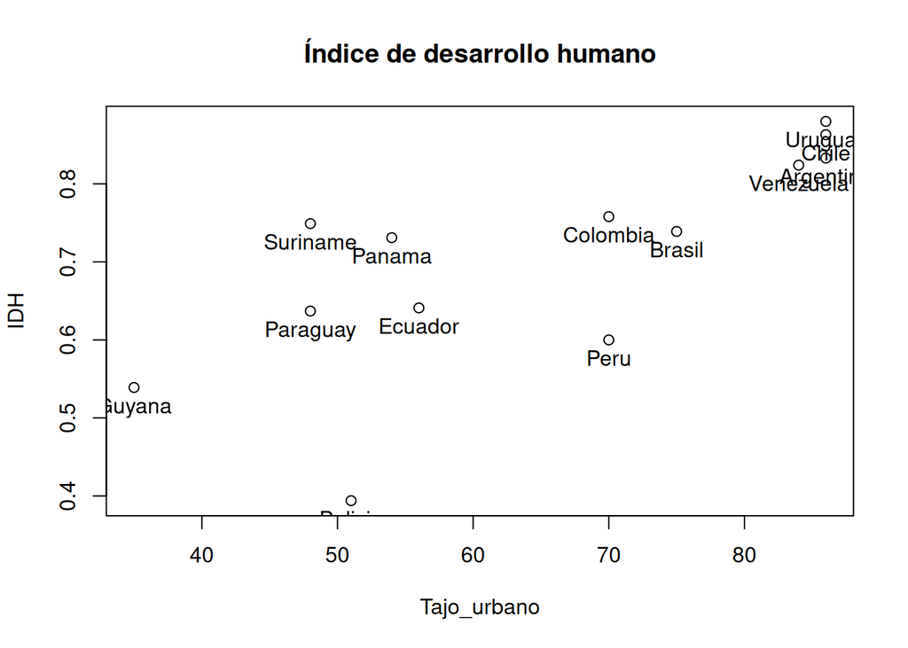

```r
attach(SudAmerica)
plot(Tajo_urbano,IDH,xlab="Tajo_urbano",ylab="IDH",
     main="Índice de desarrollo humano")                    # diagrama
  text(Tajo_urbano,IDH,labels=rownames(SudAmerica),pos=1)   # con etiquetas
```

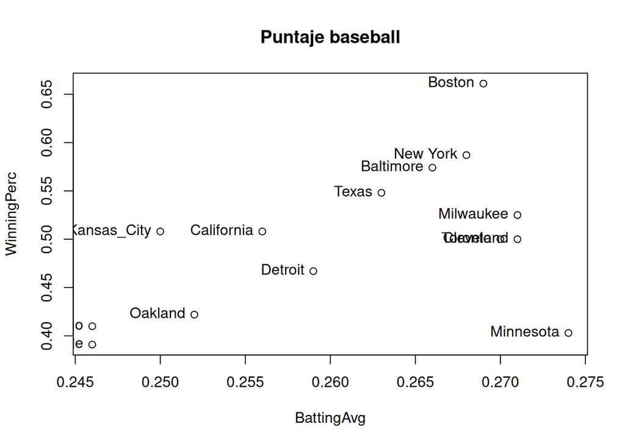

```r
detach(SudAmerica)
###############
attach(Baseball)
plot(BattingAvg,WinningPerc,xlab="BattingAvg",
     ylab="WinningPerc",main="Puntaje baseball")            # diagrama
  text(BattingAvg,WinningPerc,labels=rownames(Baseball),
       pos=2)                                               # con etiquetas
```

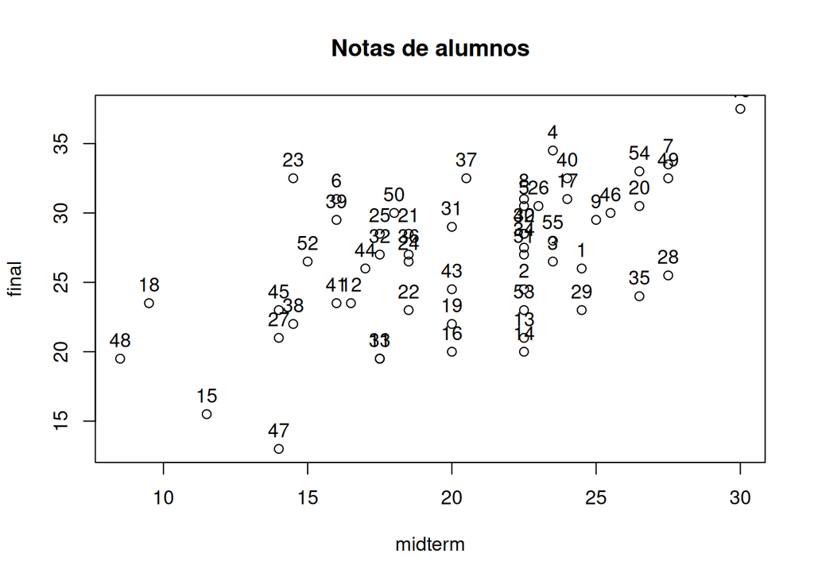

```r
detach(Baseball)
###############
attach(Students)
plot(midterm,final,xlab="midterm",ylab="final",
     main="Notas de alumnos")                               # diagrama
  text(midterm,final,labels=rownames(Students),pos=3)       # con etiquetas
```

```r
detach(Students)
```

Los gráficos representan la distribución conjunta de las pareja de carácteres observados en los tres archivos.

# Siempre en Ejercicio_1.Rmd

correr regresiones con lm sobre dos de los archivos cargados, usando la sintaxis criterio~descriptor.

```r
attach(SudAmerica)
lmSA               <- lm(IDH~Tajo_urbano,data=SudAmerica)   # regresión
summary(lmSA)
```

```
##
## Call:
## lm(formula = IDH ~ Tajo_urbano, data = SudAmerica)
##
## Residuals:
##      Min       1Q   Median       3Q      Max
## -0.22772 -0.01044  0.01240  0.03322  0.14512
##
## Coefficients:
##             Estimate Std. Error t value Pr(>|t|)
## (Intercept) 0.318545   0.108546   2.935  0.01358 *
## Tajo_urbano 0.005945   0.001609   3.694  0.00354 **
## ---
## Signif. codes:  0 '***' 0.001 '**' 0.01 '*' 0.05 '.' 0.1 ' ' 1
##
## Residual standard error: 0.098 on 11 degrees of freedom
## Multiple R-squared:  0.5537, Adjusted R-squared:  0.5131
## F-statistic: 13.65 on 1 and 11 DF,  p-value: 0.003537
```

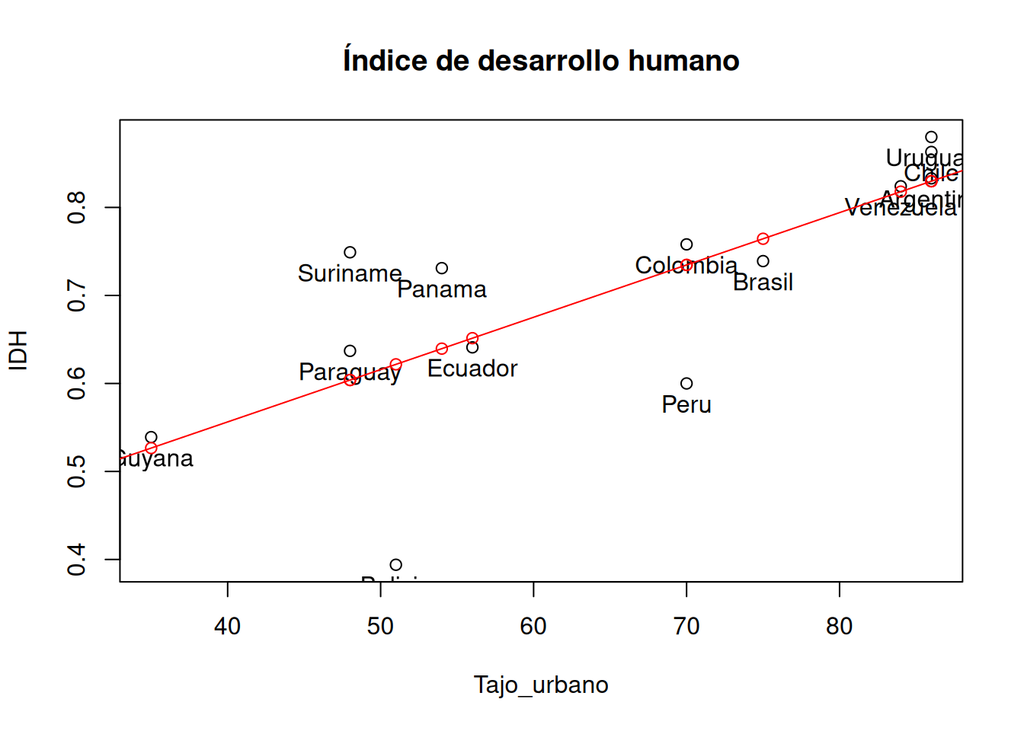

```r
plot(Tajo_urbano,IDH,xlab="Tajo_urbano",ylab="IDH",
     main="Índice de desarrollo humano")                    # diagrama
  text(Tajo_urbano,IDH,labels=rownames(SudAmerica),pos=1)   # con etiquetas
  abline(lmSA,col="red")                                    # recta estimada
  points(Tajo_urbano,lmSA$fitted.values,col="red")          # y los IDH estimados
```

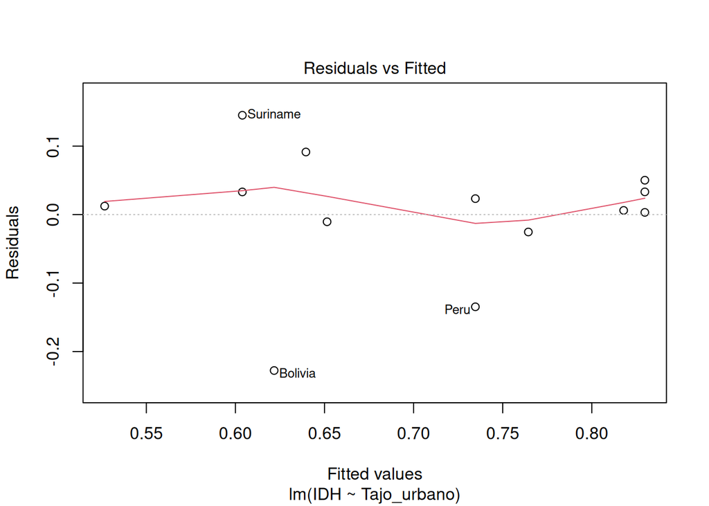

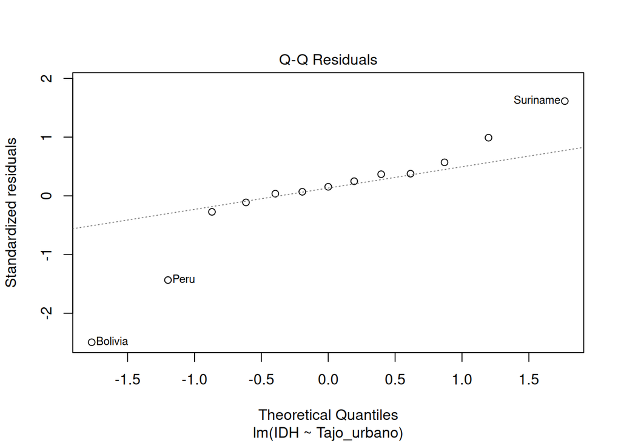

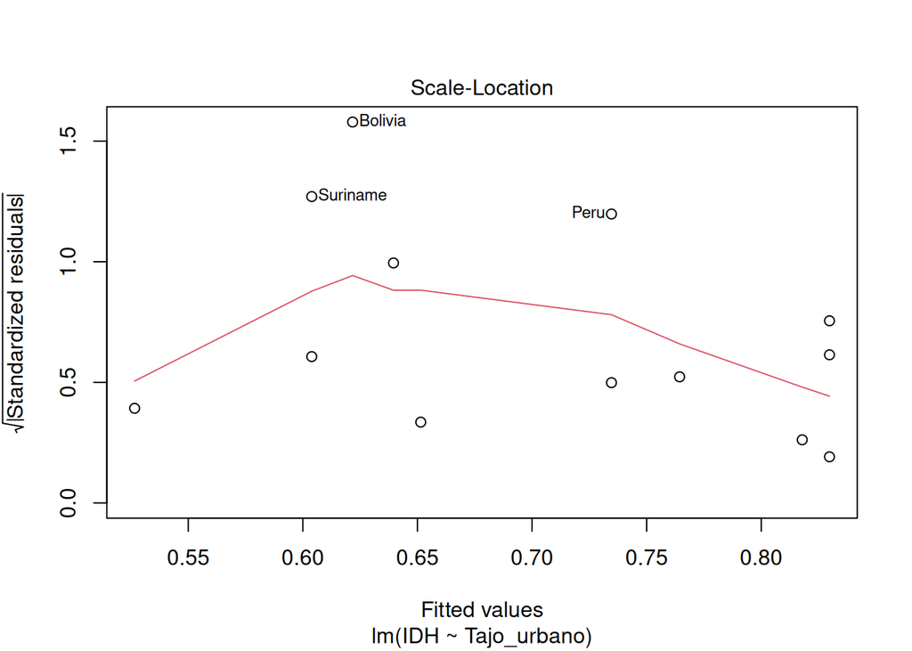

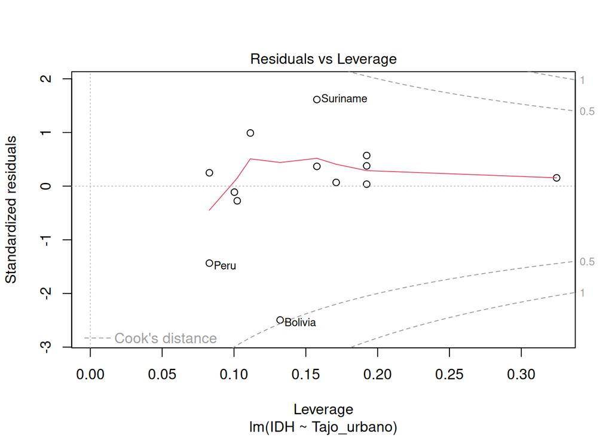

```r
plot(lmSA)
```

```r
detach(SudAmerica)
```

La salida de la regresión proporciona los parámetros de la recta de mínimos cuadratos que estima el IDH bajo el tajo urbano.

El primero gráfico muestra la recta misma y la posición estimada de los países. Se pueden apreciar en particular los países mal estimados que se encuentran lejos de la misma.

Los otros gráficos sirven para diagnósticos, para observar la calidad del modelo, bajo la distribución de los resíduos.

```r
attach(Baseball)
lmBase             <- lm(WinningPerc~BattingAvg,
                         data=Baseball)                     # regresión
summary(lmBase)
```

```
##
## Call:
## lm(formula = WinningPerc ~ BattingAvg, data = Baseball)
##
## Residuals:
##      Min       1Q   Median       3Q      Max
## -0.14627 -0.03653 -0.01800  0.05004  0.13132
##
## Coefficients:
##             Estimate Std. Error t value Pr(>|t|)
## (Intercept)  -0.5245     0.5154  -1.018   0.3289
## BattingAvg    3.9189     1.9694   1.990   0.0699 .
## ---
## Signif. codes:  0 '***' 0.001 '**' 0.01 '*' 0.05 '.' 0.1 ' ' 1
##
## Residual standard error: 0.07017 on 12 degrees of freedom
## Multiple R-squared:  0.2481, Adjusted R-squared:  0.1854
## F-statistic: 3.959 on 1 and 12 DF,  p-value: 0.06989
```

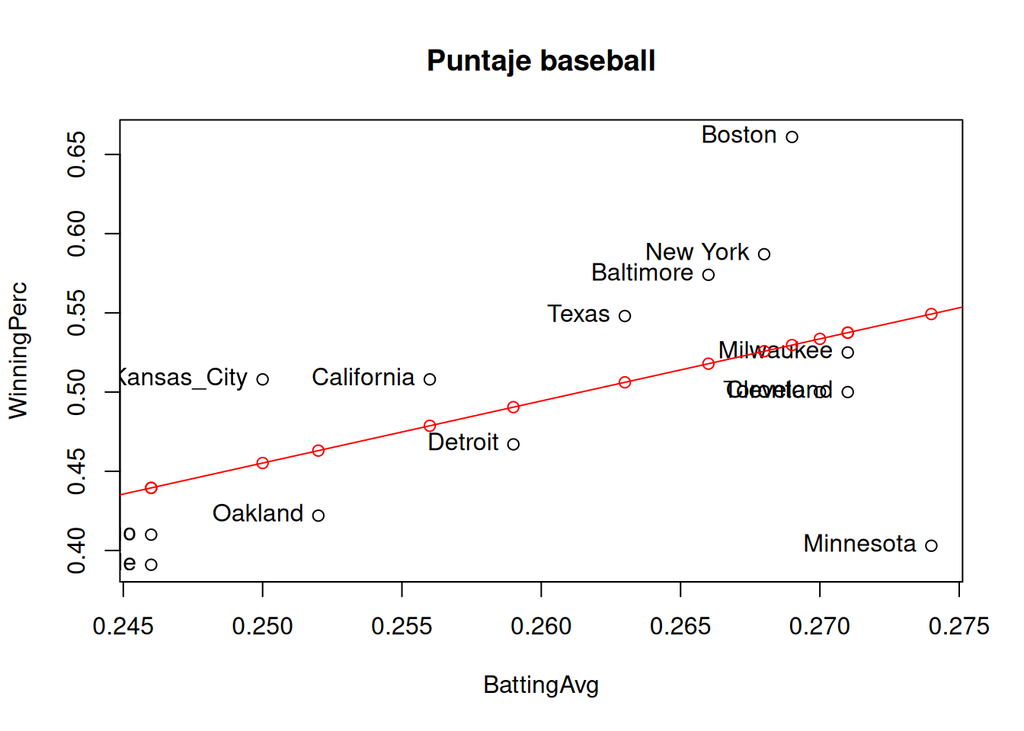

```r
plot(BattingAvg,WinningPerc,xlab="BattingAvg",
     ylab="WinningPerc",main="Puntaje baseball")            # diagrama
  text(BattingAvg,WinningPerc,labels=rownames(Baseball),
       pos=2)                                               # con etiquetas
  abline(lmBase,col="red")                                  # recta estimada
  points(BattingAvg,lmBase$fitted.values,col="red")         # y las perc estimadas
```

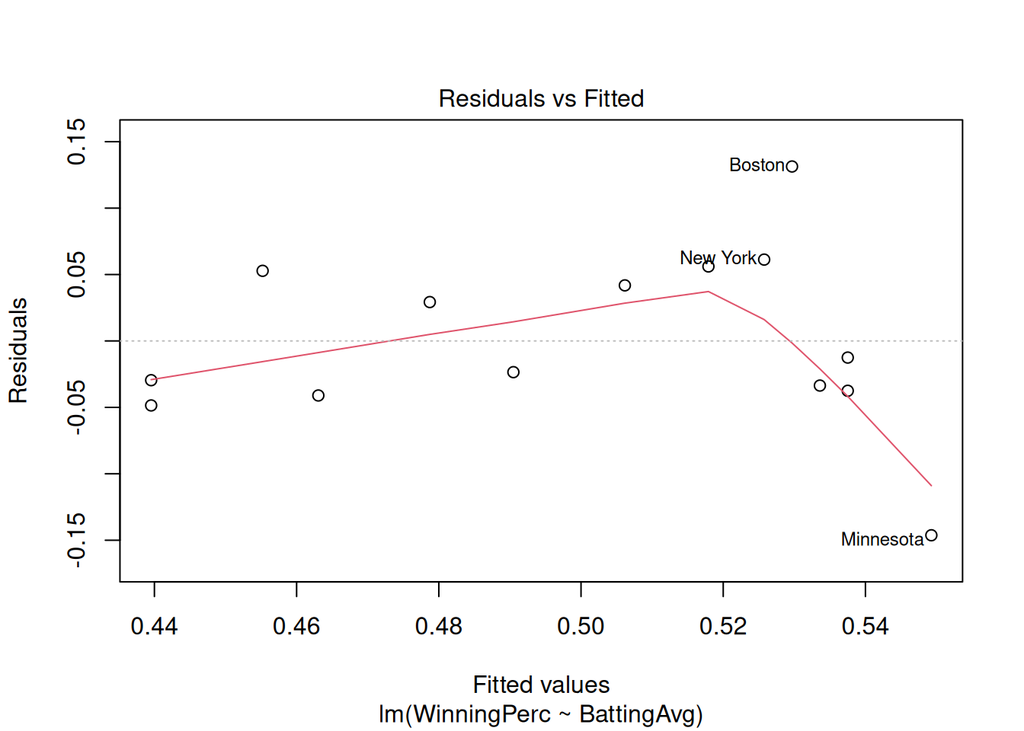

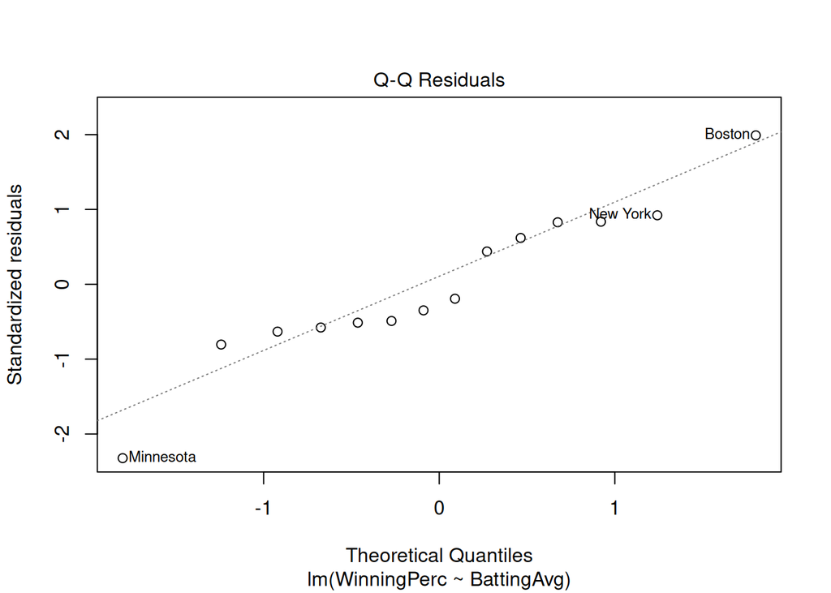

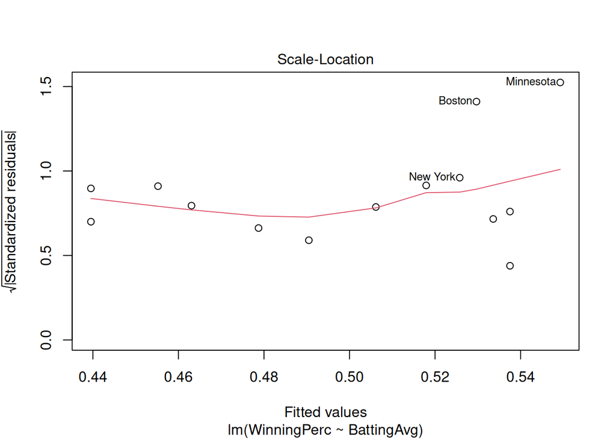

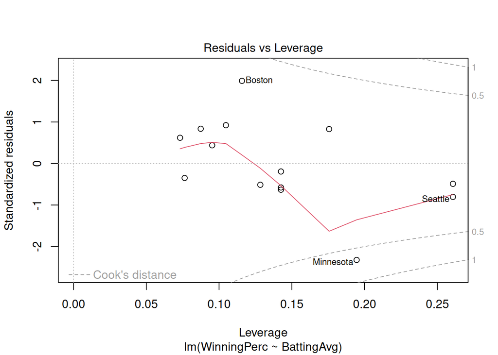

```r
plot(lmBase)
```

```r
detach(Baseball)
```

La salida de la regresión proporciona los parámetros de la recta de mínimos cuadratos que estima el porcentaje de victorias en relación con los promedios de otro indicador.

```r
attach(Students)
lmStud             <- lm(final~midterm,data=Students)       # regresión
summary(lmStud)
```

```
##
## Call:
## lm(formula = final ~ midterm, data = Students)
##
## Residuals:
##    Min     1Q Median     3Q    Max
## -9.932 -2.657  0.527  2.984  9.286
##
## Coefficients:
##             Estimate Std. Error t value Pr(>|t|)
## (Intercept)  15.0462     2.4822   6.062 1.44e-07 ***
## midterm       0.5633     0.1190   4.735 1.67e-05 ***
## ---
## Signif. codes:  0 '***' 0.001 '**' 0.01 '*' 0.05 '.' 0.1 ' ' 1
##
## Residual standard error: 4.192 on 53 degrees of freedom
## Multiple R-squared:  0.2973, Adjusted R-squared:  0.284
## F-statistic: 22.42 on 1 and 53 DF,  p-value: 1.675e-05
```

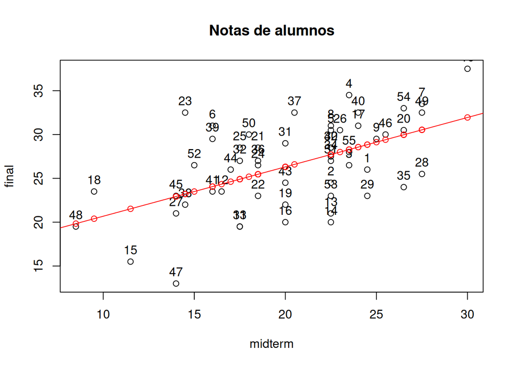

```r
plot(midterm,final,xlab="midterm",ylab="final",
     main="Notas de alumnos")                               # diagrama
  text(midterm,final,labels=rownames(Students),pos=3)       # con etiquetas
  abline(lmStud,col="red")                                  # recta estimada
  points(midterm,lmStud$fitted.values,col="red")            # y las notas estimadas
```

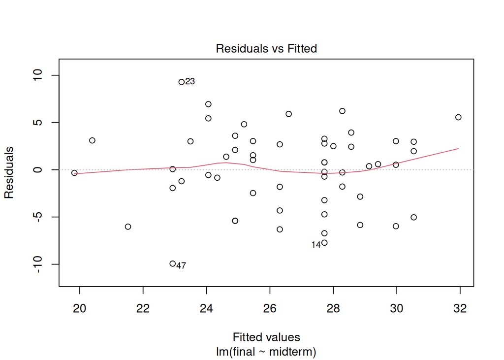

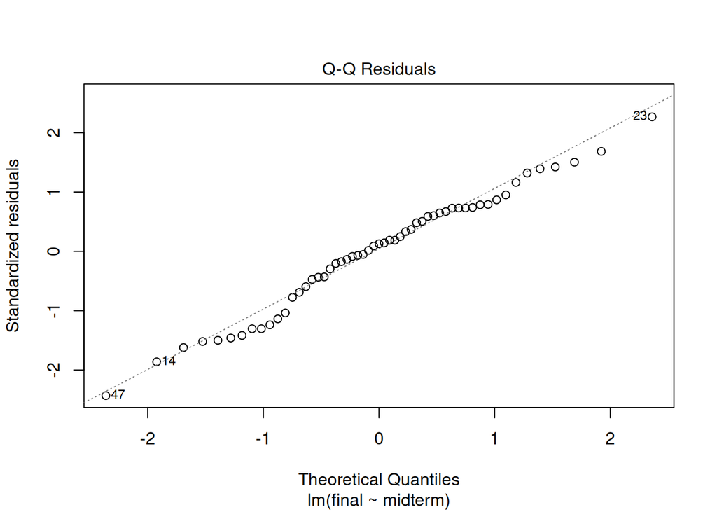

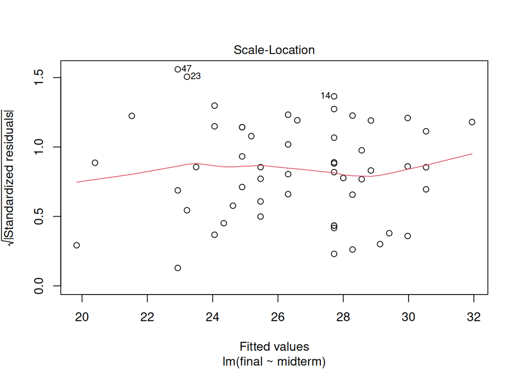

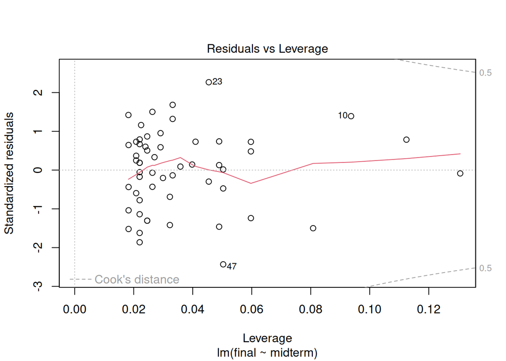

```r
plot(lmStud)
```

```r
detach(Students)
```

Aquí se observan los resultados de la regresión de las notas finales estimadas bajo los parciales.

Comparando los resultados de las tres regresiones, en particular el $R^2$ que indica la parte de variable criterio explicada para el regresór, se ve que el primero modelo explica más del 50% del IDH, mientras los demás solo explican al rededor de 25% en ambos casos.

Por otro lado los residuos de los alumnos parecen ser más regulares, signo que aún explique una parte limitada de la nota final, el modelo parece resultar de calidad mejor.

# Construir Ejercicio_1.html

con el comando knitr, guardar los archivos .Rmd y .html y enviar-los a sergio@camiz.it dentro del 13 de Abril a las 23:59.